# ECO 602 Final Project

#### Histograms of body mass and body length

Lets create two histograms to examine the distribution of delomys body length and delomys body mass.

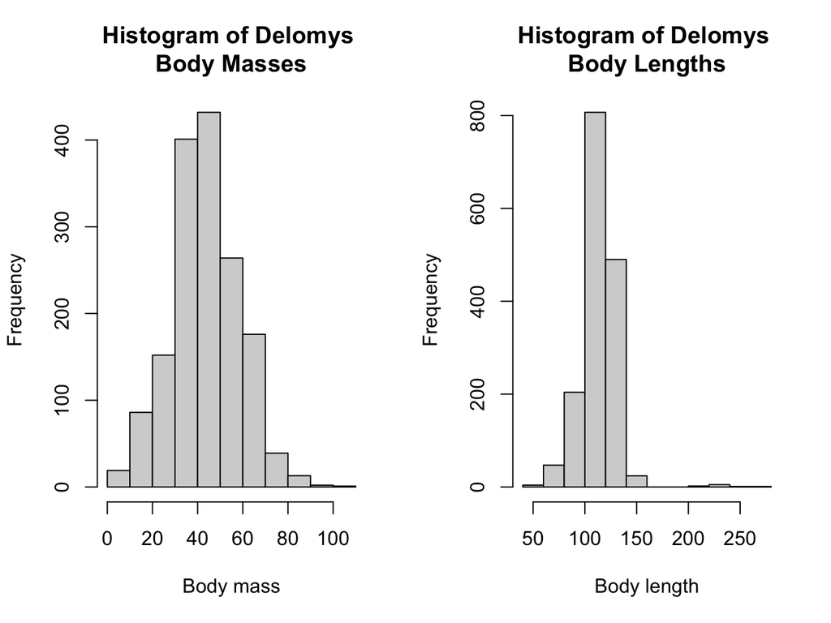

```r
par(mfrow = c(1,2)) # sets graphical parameters

hist(delomys$body_mass, main = "Histogram of Delomys \nBody Masses", xlab = "Body mass")

hist(delomys$body_length, main = "Histogram of Delomys \nBody Lengths", xlab = "Body length")
```

```r
dev.off() # don't forget to reset your graphical parameters!
```

#### Boxplots of body mass

We will now create boxplots to examine the distribution of delomys body masses in relation to two categorical variables (namely, species and sex). Do delomys of different species and sexes differ in body mass? Let’s find out.

First, we can create a boxplot of body mass conditioned on species.

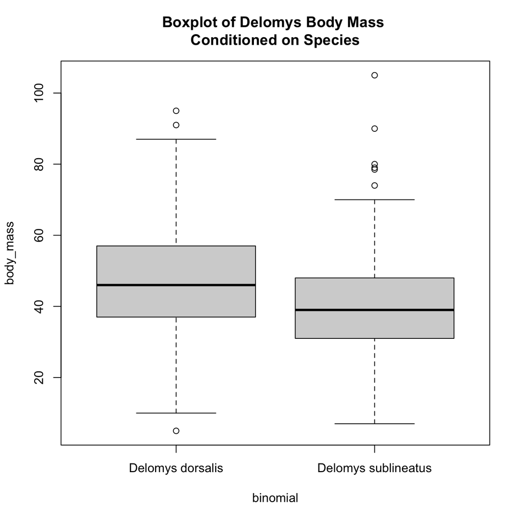

```r
boxplot(body_mass ~ binomial, data = delomys, main = "Boxplot of Delomys Body Mass \nConditioned on Species")
```

Compare the previous plot to a boxplot of body mass conditioned on sex.

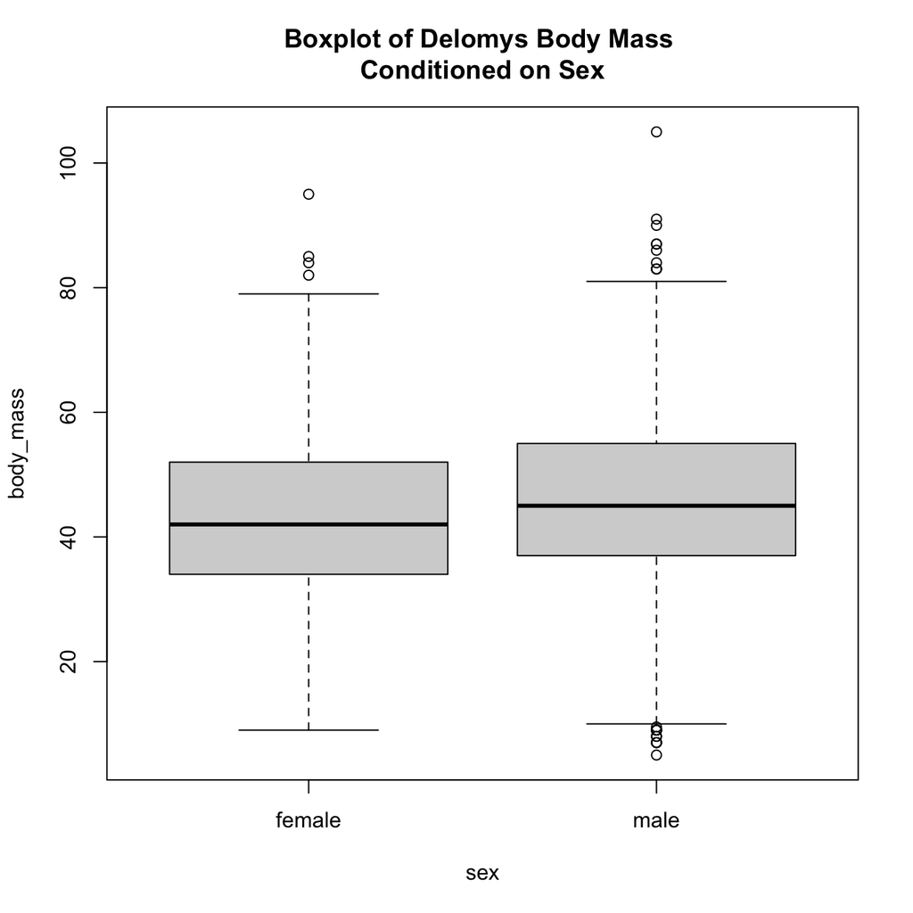

```r
boxplot(body_mass ~ sex, data = delomys, main = "Boxplot of Delomys Body Mass \nConditioned on Sex")
```

Note whether there is any evidence of differences in body mass based on species or sex.

We can extend the application of the boxplot by conditioning body mass on both species and sex.

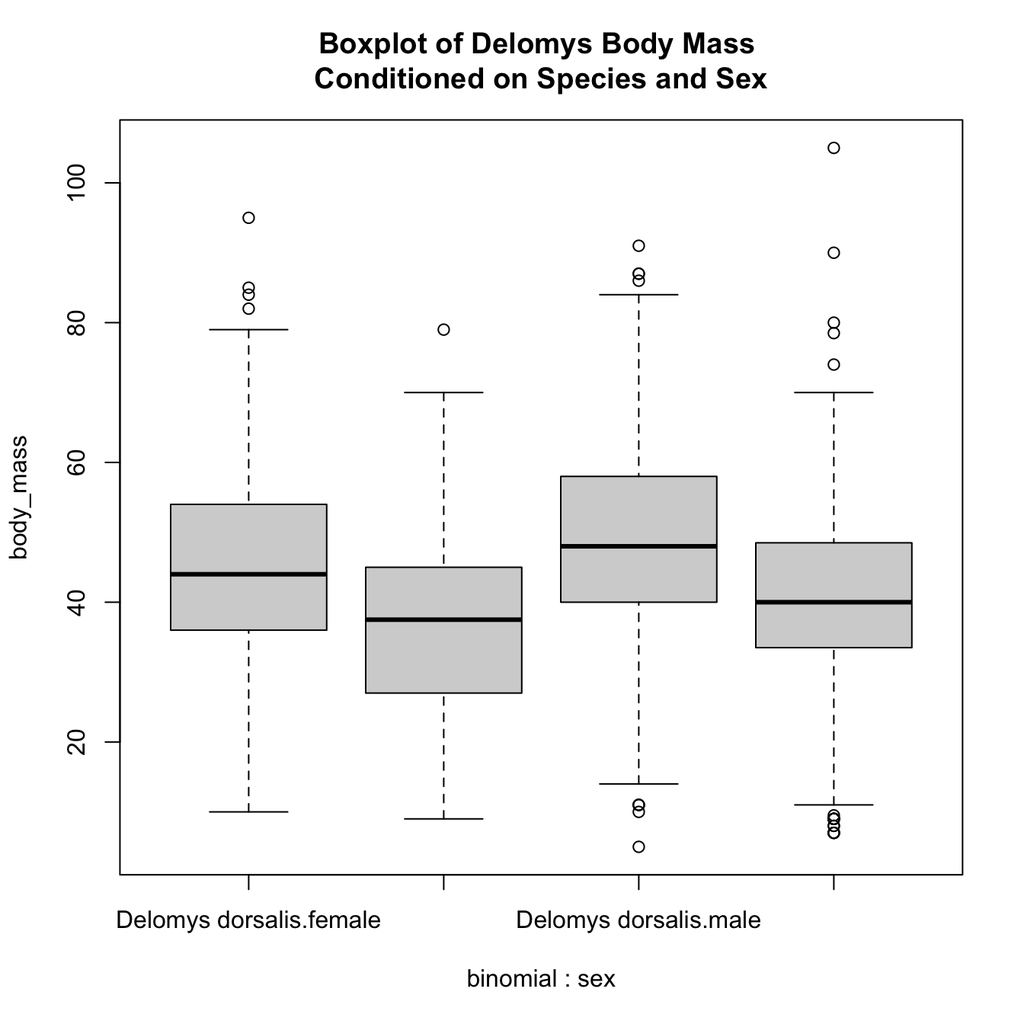

```r
boxplot(body_mass ~ binomial * sex, data = delomys, main = "Boxplot of Delomys Body Mass \nConditioned on Species and Sex")
```

## Model Building

Now that we have sufficiently explored our data, we can proceed with model building. Model building is an iterative process, so let’s fit five different models to describe the relationship between delomys body mass and body length.

### Model 1: A simple linear regression between delomys body length and body mass.

```r
# In this model, body length is a function of body mass.

fit1 <- lm(body_length ~ body_mass, data = delomys)
anova(fit1)
```

```
## Analysis of Variance Table
##
## Response: body_length
##             Df Sum Sq Mean Sq F value    Pr(>F)
## body_mass    1 269389  269389    1977 < 2.2e-16 ***
## Residuals 1583 215707     136
## ---
## Signif. codes:  0 '***' 0.001 '**' 0.01 '*' 0.05 '.' 0.1 ' ' 1
```

### Model 2: A one-way ANOVA of delomys body mass, conditioned on sex.

```r
# Body mass is a function of sex in this model.
fit2 <- lm(body_mass ~ sex, data = delomys)
anova(fit2)
```

```
## Analysis of Variance Table
##
## Response: body_mass
##             Df Sum Sq Mean Sq F value    Pr(>F)
## sex          1   3062 3061.68  13.943 0.0001951 ***
## Residuals 1578 346507  219.59
## ---
## Signif. codes:  0 '***' 0.001 '**' 0.01 '*' 0.05 '.' 0.1 ' ' 1
```

### Model 3: A one-way ANOVA of delomys body mass, conditioned on species.

```r
# Body mass is a function of species in this model.
fit3 <- lm(body_mass ~ binomial, data = delomys)
anova(fit3)
```

```
## Analysis of Variance Table
##
## Response: body_mass
##             Df Sum Sq Mean Sq F value    Pr(>F)
## binomial     1  21290 21289.7  102.08 < 2.2e-16 ***
## Residuals 1583 330164   208.6
## ---
## Signif. codes:  0 '***' 0.001 '**' 0.01 '*' 0.05 '.' 0.1 ' ' 1
```

### Model 4: A two-way additive ANOVA of delomys body mass, conditioned on sex and species.

```r
# Body mass is a function of sex and species in this model.
fit4 <- lm(body_mass ~ sex + binomial, data = delomys)
anova(fit4)
```

```
## Analysis of Variance Table
##
## Response: body_mass
##             Df Sum Sq Mean Sq F value    Pr(>F)
## sex          1   3062  3061.7  14.958 0.0001144 ***
## binomial     1  23727 23727.1 115.923 < 2.2e-16 ***
## Residuals 1577 322780   204.7
## ---
## Signif. codes:  0 '***' 0.001 '**' 0.01 '*' 0.05 '.' 0.1 ' ' 1
```

### Model 5: A two-way factorial ANOVA of delomys body mass, conditioned on sex and species.

```r
# In this case, there is an interactive effect between sex and species.
fit5 <- lm(body_mass ~ sex * binomial, data = delomys)
anova(fit5)
```

```
## Analysis of Variance Table
##
## Response: body_mass
##                Df Sum Sq Mean Sq  F value    Pr(>F)
## sex             1   3062  3061.7  14.9489  0.000115 ***
## binomial        1  23727 23727.1 115.8500 < 2.2e-16 ***
## sex:binomial    1      1     0.8   0.0039  0.950442
## Residuals    1576 322779   204.8
## ---
## Signif. codes:  0 '***' 0.001 '**' 0.01 '*' 0.05 '.' 0.1 ' ' 1
```

## Model Diagnostics

We will first visually inspect model residuals by creating histograms to display residual distributions…

[output not shown]

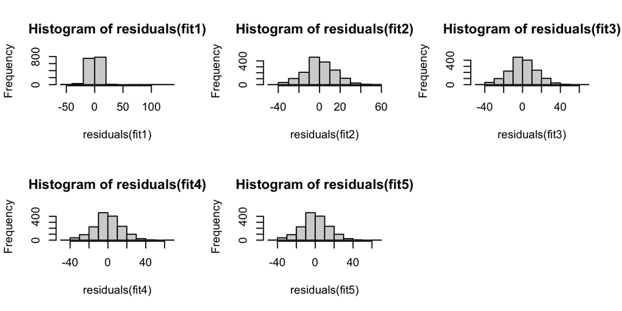

```r
par(mfrow = c(2,3))
hist(residuals(fit1))
hist(residuals(fit2))
hist(residuals(fit3))
hist(residuals(fit4))
hist(residuals(fit5))
dev.off
```

We can then conduct shapiro tests on the model residuals to statistically support observed distributions.

```r
shapiro.test(residuals(fit1))
```

```
##
##  Shapiro-Wilk normality test
##
## data:  residuals(fit1)
## W = 0.73462, p-value < 2.2e-16
```

```r
shapiro.test(residuals(fit2))
```

```
##
##  Shapiro-Wilk normality test
##
## data:  residuals(fit2)
## W = 0.99563, p-value = 0.0001541
```

```r
shapiro.test(residuals(fit3))
```

```
##
##  Shapiro-Wilk normality test
##
## data:  residuals(fit3)
## W = 0.99535, p-value = 8.103e-05
```

```r
shapiro.test(residuals(fit4))
```

```
##
##  Shapiro-Wilk normality test
##
## data:  residuals(fit4)
## W = 0.99525, p-value = 6.805e-05
```

```r
shapiro.test(residuals(fit5))
```

```
##
##  Shapiro-Wilk normality test
##
## data:  residuals(fit5)
## W = 0.99526, p-value = 6.816e-05
```

## Model Interpretation

Since we have fit our five models, we can now interpret and compare them.

### Body Length

Our first model (fit1) is a simple linear regression in which delomys body length is a function of body mass. We will use summary() to view the results of the model.

```r
# Recall: fit1 <- lm(body_length ~ body_mass, data = delomys)

knitr::kable(coef(summary(fit1))) # coef() is used to extract model coefficients from the summary table. # knitr::kable() is used for formatting.
```

|  | Estimate | Std. Error | t value | Pr(>\|t\|) |
| --- | --- | --- | --- | --- |
| (Intercept) | 76.1246565 | 0.9158120 | 83.12258 | 0 |
| body_mass | 0.8754988 | 0.0196905 | 44.46298 | 0 |

Test yourself:

Q: What is the magnitude of the mass/length relationship? - A: 0.8755

Q: What is the expected body length of an an animal that weighs 100g? - Recall: y = mx + b - A: 76.1247 + 0.8755(100) = 163.6745

Q: What is the expected body length of an animal that weighs 0g? - The predicted y-intercept is the expected body length. - A: 76.1247

### Body Mass: Model Coefficients

We will now examine the model coefficient tables for each of the body mass model fits.

Model 2: A one-way ANOVA of delomys body mass, conditioned on sex. Recall: fit2 <- lm(body_mass ~ sex, data = delomys)

```r
knitr::kable(coef(summary(fit2)))
```

|  | Estimate | Std. Error | t value | Pr(>\|t\|) |
| --- | --- | --- | --- | --- |
| (Intercept) | 42.711465 | 0.5288929 | 80.756355 | 0.0000000 |
| sexmale | 2.784133 | 0.7456117 | 3.734024 | 0.0001951 |

Model 3: A one-way ANOVA of delomys body mass, conditioned on species. Recall: fit3 <- lm(body_mass ~ binomial, data = delomys)

```r
knitr::kable(coef(summary(fit3)))
```

|  | Estimate | Std. Error | t value | Pr(>\|t\|) |
| --- | --- | --- | --- | --- |
| (Intercept) | 46.752427 | 0.4499933 | 103.89582 | 0 |
| binomialDelomys sublineatus | -7.683058 | 0.7604562 | -10.10322 | 0 |

Model 4: A two-way additive ANOVA of delomys body mass, conditioned on sex and species. Recall: fit4 <- lm(body_mass ~ sex + binomial, data = delomys)

```r
knitr::kable(coef(summary(fit4)))
```

|  | Estimate | Std. Error | t value | Pr(>\|t\|) |
| --- | --- | --- | --- | --- |
| (Intercept) | 45.070355 | 0.5556429 | 81.113891 | 0e+00 |
| sexmale | 3.795395 | 0.7259609 | 5.228099 | 2e-07 |
| binomialDelomys sublineatus | -8.193492 | 0.7609985 | -10.766764 | 0e+00 |

Model 5: A two-way factorial ANOVA of delomys body mass, conditioned on sex and species. Recall: fit5 <- lm(body_mass ~ sex * binomial, data = delomys)

```r
knitr::kable(coef(summary(fit5)))
```

|  | Estimate | Std. Error | t value | Pr(>\|t\|) |
| --- | --- | --- | --- | --- |
| (Intercept) | 45.0554562 | 0.6052973 | 74.4352459 | 0.0000000 |
| sexmale | 3.8280908 | 0.8966667 | 4.2692460 | 0.0000208 |
| binomialDelomys sublineatus | -8.1417394 | 1.1281046 | -7.2171847 | 0.0000000 |
| sexmale:binomialDelomys sublineatus | -0.0950187 | 1.5285856 | -0.0621612 | 0.9504424 |

Q: What is the base level for sex? - A: Female.

Q: What is the base level for binomial? - A: Delomys dorsalis.

Q: Which sex is heavier? - A: Male.

Q: Which species is heavier? - A: Delomys dorsalis.

### Body Mass: ANOVA

Model 2: A one-way ANOVA of delomys body mass, conditioned on sex.

```r
# Recall: fit2 <- lm(body_mass ~ sex, data = delomys)
knitr::kable(anova(fit2))
```

|  | Df | Sum Sq | Mean Sq | F value | Pr(>F) |
| --- | --- | --- | --- | --- | --- |
| sex | 1 | 3061.678 | 3061.6779 | 13.94294 | 0.0001951 |
| Residuals | 1578 | 346507.131 | 219.5863 | NA | NA |

Model 3: A one-way ANOVA of delomys body mass, conditioned on species.

```r
# Recall: fit3 <- lm(body_mass ~ binomial, data = delomys)
knitr::kable(anova(fit3))
```

|  | Df | Sum Sq | Mean Sq | F value | Pr(>F) |
| --- | --- | --- | --- | --- | --- |
| binomial | 1 | 21289.68 | 21289.6805 | 102.0751 | 0 |
| Residuals | 1583 | 330164.45 | 208.5688 | NA | NA |

Model 4: A two-way additive ANOVA of delomys body mass, conditioned on sex and species.

```r
# Recall: fit4 <- lm(body_mass ~ sex + binomial, data = delomys)
knitr::kable(anova(fit4))
```

|  | Df | Sum Sq | Mean Sq | F value | Pr(>F) |
| --- | --- | --- | --- | --- | --- |
| sex | 1 | 3061.678 | 3061.6779 | 14.95838 | 0.0001144 |
| binomial | 1 | 23727.134 | 23727.1342 | 115.92320 | 0.0000000 |
| Residuals | 1577 | 322779.997 | 204.6798 | NA | NA |

Model 5: A two-way factorial ANOVA of delomys body mass, conditioned on sex and species.

```r
# Recall: fit5 <- lm(body_mass ~ sex * binomial, data = delomys)
knitr::kable(anova(fit5))
```

|  | Df | Sum Sq | Mean Sq | F value | Pr(>F) |
| --- | --- | --- | --- | --- | --- |
| sex | 1 | 3.061678e+03 | 3.061678e+03 | 14.948932 | 0.0001150 |
| binomial | 1 | 2.372713e+04 | 2.372713e+04 | 115.849977 | 0.0000000 |
| sex:binomial | 1 | 7.913846e-01 | 7.913846e-01 | 0.003864 | 0.9504424 |
| Residuals | 1576 | 3.227792e+05 | 2.048091e+02 | NA | NA |

Q: Are sex and species significant predictors for body mass? - A: Yes (p-value < 0.05 for both factors).

Q: Is there a significant interaction? - A: No (p-value > 0.05 for interactive effect).

Q: Does the significance (as measured by p-value) of either of the main effects (sex and species) differ much between the single-predictor models, the additive model, and the interactive model? - A: The significance of sex differed very slightly between the model conditioned on sex alone (fit2) and the model conditioned on sex and species with no interaction (fit4). The significance of the species effect is consistent between models.

### Model Comparison: Body Mass

```r
AICvec <- c(AIC(fit2), AIC(fit3), AIC(fit4), AIC(fit5))
AICvec
```

```
## [1] 13006.80 12966.36 12896.73 12898.72
```

Q: Which two models have the lowest AIC? - A: fit4 and fit5 have the two lowest AICs.

Q: Which of the two models with lowest AIC scores would you select? - A: I would select fit4: the two-way additive ANOVA of body mass conditioned on sex and species.

Q: Explain your decision based on model fit and the complexity/understanding trade-off. - A: fit4 is a better model than fit5 for the purpose of predicting delomys body mass on the basis of sex and species. fit4 has an AIC comparable to that of fit5, but fit5 has an interactive effect while fit4 does not. The absence of this interactive effect gives fit4 an advantage. Simpler models are easier to explain and interpret, and the absence of the interactive effect does not reduce model performance.